# Online Retail Customer Analytics

Madhu Mitha

# Project Overview

This project presents an end-to-end analysis of online retail transaction data to understand customer purchasing behavior, revenue performance, geographic activity, product performance, cancellations, data quality, and transaction patterns.

The analysis was completed in R using data wrangling, exploratory data analysis, aggregation, feature engineering, and visualization techniques to transform raw transaction data into business-focused insights.

```r
knitr::opts_chunk$set(
  echo = TRUE,
  message = FALSE,
  warning = FALSE
)

library(dplyr)
library(ggplot2)
```

# Data Import

The dataset contains transaction-level records from a UK-based online retailer, including invoice information, products, quantities, prices, customer identifiers, and customer countries.

```r
retail <- read.csv("../data/Online_Retail_sample.csv")

dim(retail)
```

```
## [1] 10000     8
```

```r
head(retail)
```

```
##   InvoiceNo StockCode                       Description Quantity
## 1    555200     71459    HANGING JAM JAR T-LIGHT HOLDER       24
## 2    554974     21128                GOLD FISHING GNOME        4
## 3    550972     21086       SET/6 RED SPOTTY PAPER CUPS        4
## 4    576652     22812  PACK 3 BOXES CHRISTMAS PANETTONE        3
## 5    546157     22180                    RETROSPOT LAMP        2
## 6    576200     82482 WOODEN PICTURE FRAME WHITE FINISH        2
##        InvoiceDate UnitPrice CustomerID        Country
## 1   6/1/2011 12:05      0.85      17315 United Kingdom
## 2  5/27/2011 17:14      6.95      14031 United Kingdom
## 3  4/21/2011 17:05      0.65      14031 United Kingdom
## 4 11/16/2011 10:39      1.95      17198 United Kingdom
## 5   3/10/2011 8:40      9.95      13502 United Kingdom
## 6 11/14/2011 12:14      2.95      15572 United Kingdom
```

```r
str(retail)
```

```
## 'data.frame':    10000 obs. of  8 variables:
##  $ InvoiceNo  : chr  "555200" "554974" "550972" "576652" ...
##  $ StockCode  : chr  "71459" "21128" "21086" "22812" ...
##  $ Description: chr  "HANGING JAM JAR T-LIGHT HOLDER" "GOLD FISHING GNOME" "SET/6 RED SPOTTY PAPER CUPS" "PACK 3 BOXES CHRISTMAS PANETTONE" ...
##  $ Quantity   : int  24 4 4 3 2 2 12 12 1 2 ...
##  $ InvoiceDate: chr  "6/1/2011 12:05" "5/27/2011 17:14" "4/21/2011 17:05" "11/16/2011 10:39" ...
##  $ UnitPrice  : num  0.85 6.95 0.65 1.95 9.95 2.95 0.39 1.25 6.75 1.65 ...
##  $ CustomerID : num  17315 14031 14031 17198 13502 ...
##  $ Country    : chr  "United Kingdom" "United Kingdom" "United Kingdom" "United Kingdom" ...
```

```r
summary(retail)
```

```
##      InvoiceNo         StockCode        Description       Quantity
##  Length   :10000   Length   :10000   Length   :10000   Min.   :-1350.000
##  N.unique : 6091   N.unique : 2418   N.unique : 2440   1st Qu.:    1.000
##  N.blank  :    0   N.blank  :    0   N.blank  :   31   Median :    3.000
##  Min.nchar:    6   Min.nchar:    1   Min.nchar:    0   Mean   :    9.902
##  Max.nchar:    7   Max.nchar:   12   Max.nchar:   35   3rd Qu.:   10.000
##                                                        Max.   : 2880.000
##
##     InvoiceDate      UnitPrice          CustomerID         Country
##  Length   :10000   Min.   :   0.000   Min.   :12347   Length   :10000
##  N.unique : 5943   1st Qu.:   1.250   1st Qu.:13883   N.unique :   34
##  N.blank  :    0   Median :   2.080   Median :15061   N.blank  :    0
##  Min.nchar:   13   Mean   :   3.752   Mean   :15252   Min.nchar:    3
##  Max.nchar:   16   3rd Qu.:   4.130   3rd Qu.:16781   Max.nchar:   20
##                    Max.   :1867.860   Max.   :18287
##                                       NAs    :2516
```

# Data Preparation

A transaction-level revenue measure was created by multiplying the quantity purchased by the unit price.

```r
retail <- retail %>%
  mutate(
    TransactionValue = Quantity * UnitPrice
  )

summary(retail$TransactionValue)
```

```
##     Min.  1st Qu.   Median     Mean  3rd Qu.     Max.
## -1867.86     3.40     9.78    17.25    17.40  3380.00
```

# Date & Time Feature Engineering

The invoice timestamp was converted into a date-time object and separated into additional analytical features.

```r
invoice_datetime <- strptime(
  retail$InvoiceDate,
  format = "%m/%d/%Y %H:%M",
  tz = "GMT"
)

retail <- retail %>%
  mutate(
    InvoiceDateParsed = as.Date(invoice_datetime),
    InvoiceDayOfWeek = weekdays(InvoiceDateParsed),
    InvoiceHour = as.numeric(format(invoice_datetime, "%H")),
    InvoiceMonth = as.numeric(format(invoice_datetime, "%m"))
  )
```

These features make it possible to analyze customer activity across dates, weekdays, hours, and months.

# Data Quality Analysis

Missing values were evaluated across all variables to identify potential data-quality issues.

```r
missing_percentage <- colMeans(is.na(retail)) * 100

missing_percentage
```

```
##         InvoiceNo         StockCode       Description          Quantity
##              0.00              0.00              0.00              0.00
##       InvoiceDate         UnitPrice        CustomerID           Country
##              0.00              0.00             25.16              0.00
##  TransactionValue InvoiceDateParsed  InvoiceDayOfWeek       InvoiceHour
##              0.00              0.00              0.00              0.00
##      InvoiceMonth
##              0.00
```

Missing Customer ID records were also analyzed by country.

```r
missing_customer_by_country <- retail %>%
  filter(is.na(CustomerID)) %>%
  count(Country, sort = TRUE)

missing_customer_by_country
```

```
##          Country    n
## 1 United Kingdom 2492
## 2           EIRE   11
## 3    Unspecified    5
## 4      Hong Kong    4
## 5       Portugal    2
## 6         France    1
## 7    Switzerland    1
```

This analysis helps identify where incomplete customer information is concentrated and where additional validation may be required before customer-level analysis.

# Geographic Analysis

## Transaction Activity by Country

Transaction activity was aggregated by country to understand the geographic distribution of the retailer’s business.

```r
country_transactions <- retail %>%
  count(Country, name = "Transactions") %>%
  mutate(
    Percentage = 100 * Transactions / nrow(retail)
  ) %>%
  arrange(desc(Transactions))

country_transactions %>%
  filter(Percentage > 1)
```

```
##          Country Transactions Percentage
## 1 United Kingdom         9111      91.11
## 2        Germany          188       1.88
## 3         France          182       1.82
## 4           EIRE          153       1.53
```

## Transaction Value by Country

Total transaction value was calculated for each country to identify markets generating significant revenue.

```r
country_revenue <- retail %>%
  group_by(Country) %>%
  summarise(
    TotalTransactionValue =
      sum(TransactionValue, na.rm = TRUE),
    .groups = "drop"
  ) %>%
  arrange(desc(TotalTransactionValue))

country_revenue %>%
  filter(TotalTransactionValue > 130000)
```

```
## # A tibble: 1 × 2
##   Country        TotalTransactionValue
##   <chr>                          <dbl>
## 1 United Kingdom               144964.
```

# Geographic Visualization

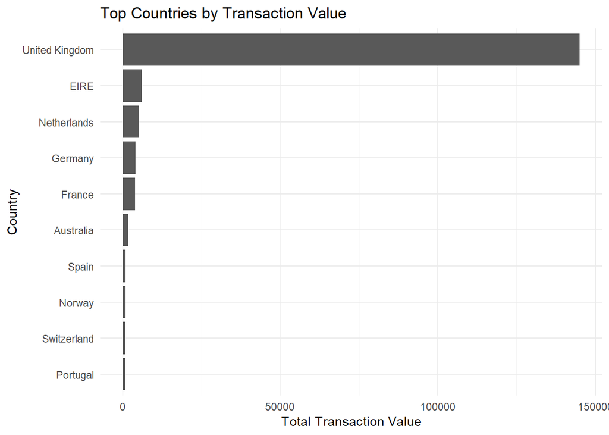

```r
top_countries <- country_revenue %>%
  slice_max(
    order_by = TotalTransactionValue,
    n = 10
  )

ggplot(
  top_countries,
  aes(
    x = reorder(Country, TotalTransactionValue),
    y = TotalTransactionValue
  )
) +
  geom_col() +
  coord_flip() +
  labs(
    title = "Top Countries by Transaction Value",
    x = "Country",
    y = "Total Transaction Value"
  ) +
  theme_minimal()
```

# Time-Based Analysis

## Transaction Activity by Day of Week

```r
weekday_transactions <- retail %>%
  group_by(InvoiceDayOfWeek) %>%
  summarise(
    Transactions = n(),
    .groups = "drop"
  ) %>%
  mutate(
    TransactionPercentage =
      100 * Transactions / sum(Transactions)
  )

weekday_transactions
```

```
## # A tibble: 6 × 3
##   InvoiceDayOfWeek Transactions TransactionPercentage
##   <chr>                   <int>                 <dbl>
## 1 Friday                   1534                  15.3
## 2 Monday                   1780                  17.8
## 3 Sunday                   1201                  12.0
## 4 Thursday                 1928                  19.3
## 5 Tuesday                  1842                  18.4
## 6 Wednesday                1715                  17.2
```

## Transaction Value by Day of Week

```r
weekday_value <- retail %>%
  group_by(InvoiceDayOfWeek) %>%
  summarise(
    TransactionValue =
      sum(TransactionValue, na.rm = TRUE),
    .groups = "drop"
  ) %>%
  mutate(
    ValuePercentage =
      100 * TransactionValue /
      sum(TransactionValue)
  )

weekday_value
```

```
## # A tibble: 6 × 3
##   InvoiceDayOfWeek TransactionValue ValuePercentage
##   <chr>                       <dbl>           <dbl>
## 1 Friday                     26617.           15.4
## 2 Monday                     30940.           17.9
## 3 Sunday                     14226.            8.25
## 4 Thursday                   37650.           21.8
## 5 Tuesday                    33943.           19.7
## 6 Wednesday                  29144.           16.9
```

## Monthly Transaction Value

```r
monthly_value <- retail %>%
  group_by(InvoiceMonth) %>%
  summarise(
    TransactionValue =
      sum(TransactionValue, na.rm = TRUE),
    .groups = "drop"
  ) %>%
  mutate(
    ValuePercentage =
      100 * TransactionValue /
      sum(TransactionValue)
  )

monthly_value
```

```
## # A tibble: 12 × 3
##    InvoiceMonth TransactionValue ValuePercentage
##           <dbl>            <dbl>           <dbl>
##  1            1           10955.            6.35
##  2            2            9068.            5.26
##  3            3           14269.            8.27
##  4            4            9115.            5.28
##  5            5           12668.            7.34
##  6            6           12323.            7.14
##  7            7           11171.            6.48
##  8            8           13373.            7.75
##  9            9           15796.            9.16
## 10           10           21106.           12.2
## 11           11           22728.           13.2
## 12           12           19947.           11.6
```

## Monthly Revenue Visualization

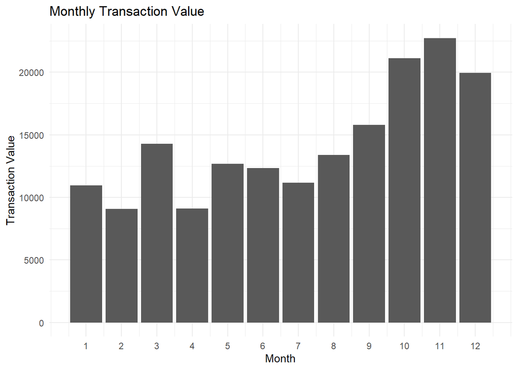

```r
ggplot(
  monthly_value,
  aes(
    x = InvoiceMonth,
    y = TransactionValue
  )
) +
  geom_col() +
  scale_x_continuous(breaks = 1:12) +
  labs(
    title = "Monthly Transaction Value",
    x = "Month",
    y = "Transaction Value"
  ) +
  theme_minimal()
```

# Australia Transaction Analysis

The date with the highest transaction activity for Australian customers was identified.

```r
australia_transactions <- retail %>%
  filter(Country == "Australia") %>%
  count(
    InvoiceDateParsed,
    name = "Transactions"
  ) %>%
  arrange(desc(Transactions))

head(australia_transactions, 1)
```

```
##   InvoiceDateParsed Transactions
## 1        2011-08-18            4
```

# Website Activity Analysis

Hourly transaction activity was evaluated to understand customer usage patterns during the IT team’s operating window.

```r
hourly_activity <- retail %>%
  filter(
    InvoiceHour >= 7,
    InvoiceHour <= 20
  ) %>%
  group_by(InvoiceHour) %>%
  summarise(
    Transactions = n(),
    .groups = "drop"
  ) %>%
  arrange(InvoiceHour)

hourly_activity
```

```
## # A tibble: 14 × 2
##    InvoiceHour Transactions
##          <dbl>        <int>
##  1           7           10
##  2           8          167
##  3           9          628
##  4          10          922
##  5          11         1091
##  6          12         1417
##  7          13         1343
##  8          14         1188
##  9          15         1438
## 10          16         1022
## 11          17          524
## 12          18          155
## 13          19           74
## 14          20           18
```

Two consecutive hours were evaluated to identify the lowest-activity maintenance window.

```r
maintenance_windows <- data.frame(
  StartHour = hourly_activity$InvoiceHour[-nrow(hourly_activity)],
  EndHour = hourly_activity$InvoiceHour[-1],
  TwoHourTransactions =
    hourly_activity$Transactions[-nrow(hourly_activity)] +
    hourly_activity$Transactions[-1]
)

maintenance_windows %>%
  arrange(TwoHourTransactions) %>%
  head(1)
```

```
##   StartHour EndHour TwoHourTransactions
## 1        19      20                  92
```

## Hourly Activity Visualization

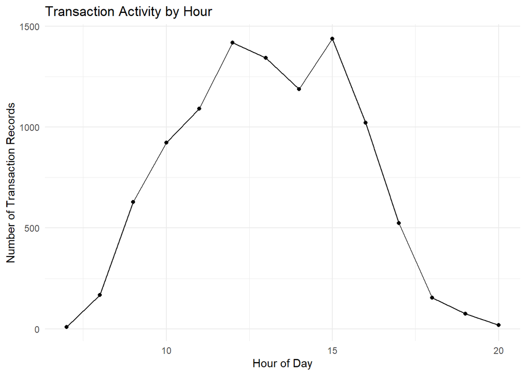

```r
ggplot(
  hourly_activity,
  aes(
    x = InvoiceHour,
    y = Transactions
  )
) +
  geom_line() +
  geom_point() +
  labs(
    title = "Transaction Activity by Hour",
    x = "Hour of Day",
    y = "Number of Transaction Records"
  ) +
  theme_minimal()
```

# Customer Analysis

Customer-level analysis excludes records where Customer ID is unavailable.

```r
customer_data <- retail %>%
  filter(!is.na(CustomerID))
```

## Most Active Customer

Customers were ranked according to the number of transaction records associated with their Customer ID.

```r
customer_activity <- customer_data %>%
  count(
    CustomerID,
    name = "TransactionRecords"
  ) %>%
  arrange(desc(TransactionRecords))

head(customer_activity, 10)
```

```
##    CustomerID TransactionRecords
## 1       17841                137
## 2       14911                116
## 3       12748                101
## 4       14096                101
## 5       15311                 52
## 6       14606                 51
## 7       14298                 42
## 8       14646                 38
## 9       18118                 34
## 10      15039                 29
```

## Highest-Value Customer

Customers were also ranked by total transaction value.

```r
customer_value <- customer_data %>%
  group_by(CustomerID) %>%
  summarise(
    TotalTransactionValue =
      sum(TransactionValue, na.rm = TRUE),
    .groups = "drop"
  ) %>%
  arrange(desc(TotalTransactionValue))

head(customer_value, 10)
```

```
## # A tibble: 10 × 2
##    CustomerID TotalTransactionValue
##         <dbl>                 <dbl>
##  1      14646                 4887.
##  2      15749                 3380
##  3      14156                 2976.
##  4      14911                 2695.
##  5      15769                 2434.
##  6      17450                 2370.
##  7      18102                 2283.
##  8      15838                 1790
##  9      16029                 1760.
## 10      14680                 1602.
```

## Unique Customers

```r
unique_customer_count <-
  n_distinct(customer_data$CustomerID)

unique_customer_count
```

```
## [1] 2433
```

# Repeat Purchase Analysis

Customer purchase dates were analyzed to estimate the number of days between consecutive shopping visits.

Multiple product rows can belong to the same customer purchase, so unique customer-date combinations are used before calculating the time between visits.

```r
customer_purchase_dates <- customer_data %>%
  filter(!is.na(InvoiceDateParsed)) %>%
  distinct(
    CustomerID,
    InvoiceDateParsed
  ) %>%
  arrange(
    CustomerID,
    InvoiceDateParsed
  )

repeat_purchase_intervals <-
  customer_purchase_dates %>%
  group_by(CustomerID) %>%
  mutate(
    DaysBetweenPurchases =
      as.numeric(
        InvoiceDateParsed -
        lag(InvoiceDateParsed)
      )
  ) %>%
  ungroup() %>%
  filter(
    !is.na(DaysBetweenPurchases),
    DaysBetweenPurchases > 0
  )

average_days_between_purchases <-
  mean(
    repeat_purchase_intervals$DaysBetweenPurchases,
    na.rm = TRUE
  )

average_days_between_purchases
```

```
## [1] 68.066
```

# Returns & Cancellation Analysis

Negative quantity values are used to identify cancelled transaction records.

The cancellation rate for French customers was calculated as the number of cancelled transaction records divided by the total number of French transaction records.

```r
france_transactions <- retail %>%
  filter(Country == "France")

france_cancellation_rate <-
  100 *
  sum(
    france_transactions$Quantity < 0,
    na.rm = TRUE
  ) /
  nrow(france_transactions)

france_cancellation_rate
```

```
## [1] 1.098901
```

# Product Performance Analysis

Products were ranked according to total transaction value to identify the retailer’s highest revenue-generating items.

```r
product_revenue <- retail %>%
  group_by(
    StockCode,
    Description
  ) %>%
  summarise(
    TotalTransactionValue =
      sum(TransactionValue, na.rm = TRUE),
    .groups = "drop"
  ) %>%
  arrange(desc(TotalTransactionValue))

head(product_revenue, 10)
```

```
## # A tibble: 10 × 3
##    StockCode Description                        TotalTransactionValue
##    <chr>     <chr>                                              <dbl>
##  1 21175     GIN + TONIC DIET METAL SIGN                        3648.
##  2 85099B    JUMBO BAG RED RETROSPOT                            2877.
##  3 47566     PARTY BUNTING                                      2116.
##  4 85099F    JUMBO BAG STRAWBERRY                               1800.
##  5 22728     ALARM CLOCK BAKELIKE PINK                          1732.
##  6 22273     FELTCRAFT DOLL MOLLY                               1706.
##  7 22423     REGENCY CAKESTAND 3 TIER                           1687.
##  8 22112     CHOCOLATE HOT WATER BOTTLE                         1514.
##  9 85123A    WHITE HANGING HEART T-LIGHT HOLDER                 1195.
## 10 22730     ALARM CLOCK BAKELIKE IVORY                         1126.
```

## Top Product Visualization

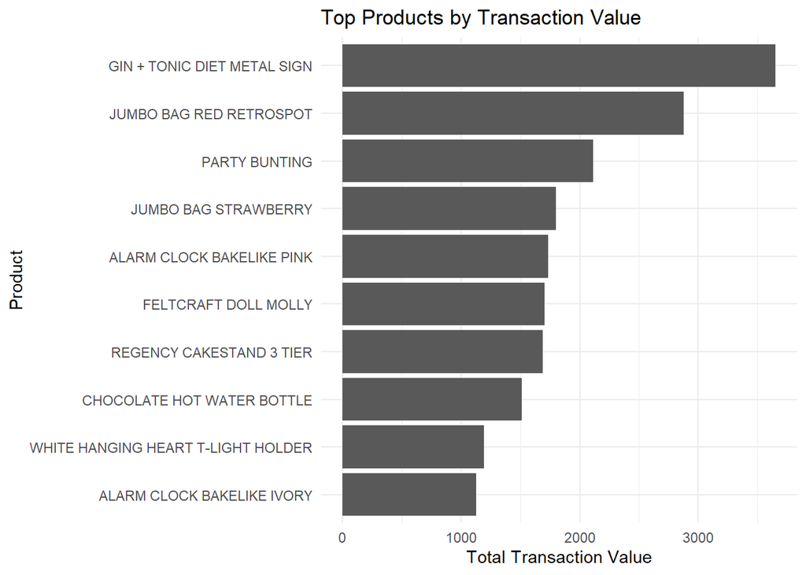

```r
top_products <- product_revenue %>%
  filter(!is.na(Description)) %>%
  slice_max(
    order_by = TotalTransactionValue,
    n = 10
  )

ggplot(
  top_products,
  aes(
    x = reorder(
      Description,
      TotalTransactionValue
    ),
    y = TotalTransactionValue
  )
) +
  geom_col() +
  coord_flip() +
  labs(
    title = "Top Products by Transaction Value",
    x = "Product",
    y = "Total Transaction Value"
  ) +
  theme_minimal()
```

# Germany Transaction Value Distribution

The distribution of transaction values for German customers was evaluated to understand the spread of transaction-level values.

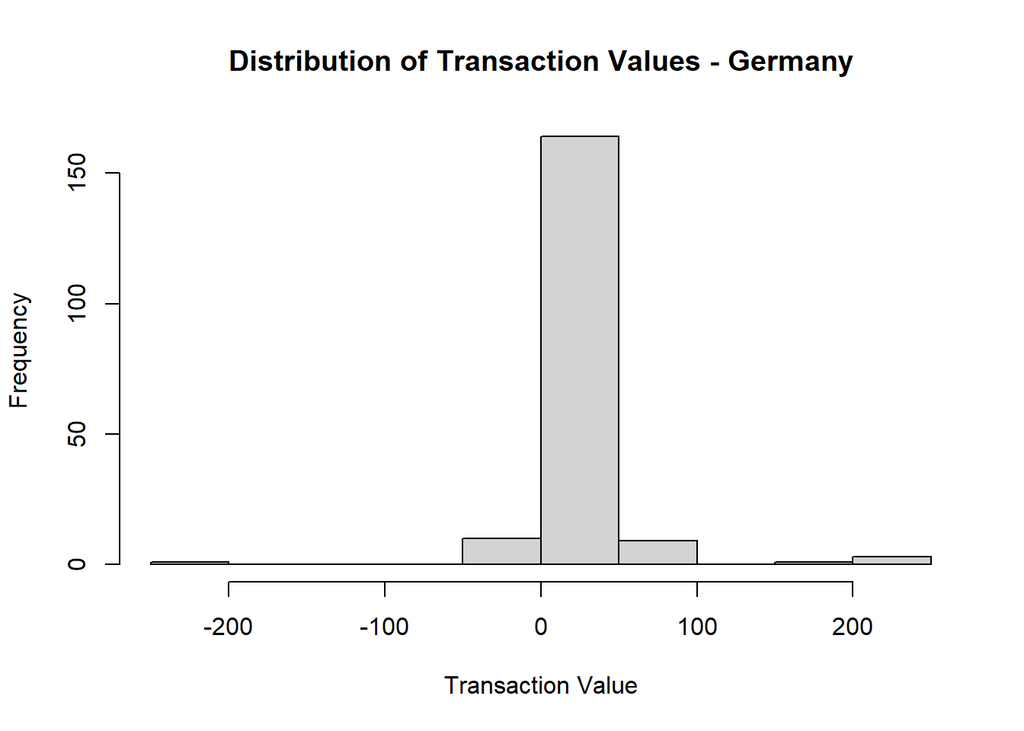

```r
germany_transactions <- retail %>%
  filter(Country == "Germany")

hist(
  germany_transactions$TransactionValue,
  main = "Distribution of Transaction Values - Germany",
  xlab = "Transaction Value"
)
```

# Key Analytical Outputs

The completed analysis provides insight into:

- Geographic concentration of transaction activity
- Revenue contribution across countries
- Customer activity and customer value
- Repeat-purchase behavior
- Product-level revenue performance
- Cancellation behavior
- Missing customer information
- Weekday and monthly transaction patterns
- Hourly customer activity
- Potential low-activity maintenance periods

# Skills Demonstrated

- R
- dplyr
- ggplot2
- Data Wrangling
- Exploratory Data Analysis
- Feature Engineering
- Descriptive Statistics
- Customer Analytics
- Revenue Analysis
- Product Analytics
- Data Quality Analysis
- Data Visualization

# Conclusion

This project demonstrates an end-to-end retail analytics workflow, beginning with raw transaction data and progressing through data preparation, quality assessment, feature engineering, customer analysis, geographic analysis, revenue analysis, product analysis, and visualization.

The analysis shows how transaction-level retail data can be transformed into actionable business insights that support customer understanding, revenue monitoring, merchandising decisions, and operational planning.